# Items selection (2)

Piotr Król

6 07 2021

Content:

- Two ways of counting correlations of responses with ages
- Correlation vs. dscrmn and category
- Low correlation <=> easy items?
- Best CTT items vs. best IRT items
- Difficulty vs. age for particular item

```r
library(CTT)
library(ltm)
library(mirt)
library(ggpubr)
```

```r
responses_demo <- read.csv("Data/responses_demo.csv", encoding = "UTF-8")
responses <- as.matrix(responses_demo[,5:ncol(responses_demo)])
cdi <- read.csv("Data/cdi.csv", encoding = "UTF-8")
```

# Two ways of counting correlations of responses with ages

Count difficulties in months intervals:

```r
dffclts_months <- c()
for (month in unique(responses_demo$months)){
  responses <- responses_demo[responses_demo$months == month, ]
  responses <- as.matrix(responses[,5:ncol(responses)])
  ctt_analysis <- itemAnalysis(responses)
  dffclts_months <- rbind(dffclts_months, ctt_analysis$itemReport$itemMean)
}
```

Count correlations of difficulties (means) by months with months:

```r
cors <- apply(dffclts_months, 2, FUN = function(x) cor(x, unique(responses_demo$months)))
cors[1:5]
```

```
## [1] 0.9227197 0.7901921 0.8133733 0.9153921 0.8649451
```

Count Pearson correlations of dichotomous responses (vector of size 2000+) with months:

```r
responses <- as.matrix(responses_demo[,5:ncol(responses_demo)])
cors2 <- apply(responses, 2, FUN = function(x) cor(x, responses_demo$months))
cors2[1:5]
```

```
##     item1     item2     item3     item4     item5
## 0.2360508 0.1217888 0.1430733 0.2488537 0.1744753
```

So, **it’s something completely different.**

Count Point-Biserial Correlations:

```r
cors3 <- apply(responses, 2, FUN = function(x) biserial.cor(responses_demo$months, x))
cors3[1:5]
```

```
##      item1      item2      item3      item4      item5
## -0.2360508 -0.1217888 -0.1430733 -0.2488537 -0.1744753
```

So, they are analogous. Just sign is different.

Let’s put both two former correlations on one plot:

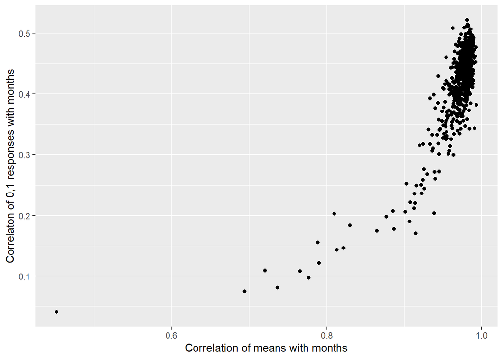

```r
ggplot(data.frame(cors1 = cors, cors2 = cors2), aes(cors1, cors2)) +
  geom_point() +
  xlab("Correlation of means with months") +
  ylab("Correlaton of 0,1 responses with months")
```

Calculate parameters with use of CTT package:

```r
ctt_analysis <- itemAnalysis(responses)
ctt_params <- data.frame(dffclt = ctt_analysis$itemReport$itemMean, dscrmn = ctt_analysis$itemReport$pBis)
ctt_params <- cbind(ctt_params, cdi)
ctt_params$cors1 <- cors
ctt_params$cors2 <- cors2
head(ctt_params)
```

```
##      dffclt    dscrmn    category number.ws number.wg position     cors1
## 1 0.5781454 0.4459347 Z01.odgłosy         1         1    gę.gę 0.9227197
## 2 0.9068350 0.2628651 Z01.odgłosy         2         2  hau.hau 0.7901921
## 3 0.8463213 0.3084193 Z01.odgłosy         3         3 ko.ko.ko 0.8133733
## 4 0.7470614 0.4437958 Z01.odgłosy         4         4  kwa.kwa 0.9153921
## 5 0.8959512 0.2918641 Z01.odgłosy         5         5     miau 0.8649451
## 6 0.7818894 0.3856947 Z01.odgłosy         6         6  mee.bee 0.9015156
##       cors2
## 1 0.2360508
## 2 0.1217888
## 3 0.1430733
## 4 0.2488537
## 5 0.1744753
## 6 0.2060606
```

Compare plots of discriminations and correlations of ages counted in two different ways:

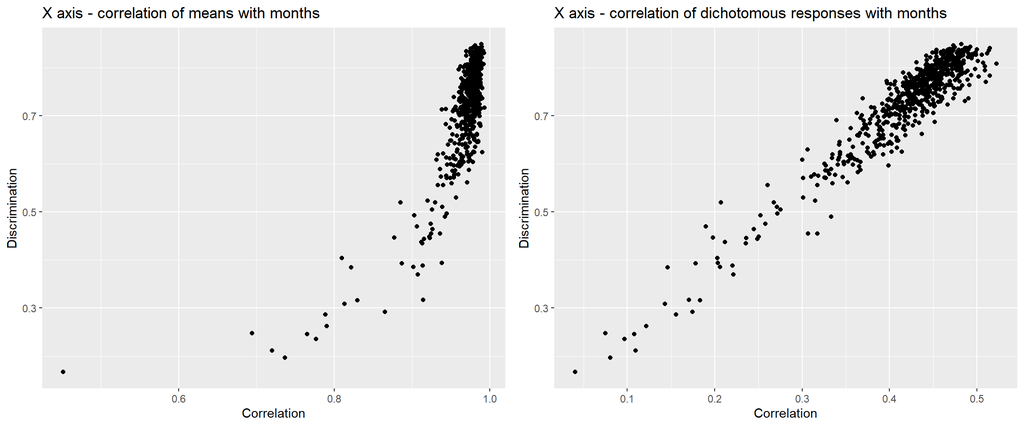

```r
plot1 <- ggplot(ctt_params, aes(cors1, dscrmn)) +
  geom_point() +
  xlab("Correlation") +
  ylab("Discrimination") +
  labs(title = "X axis - correlation of means with months")

plot2 <- ggplot(ctt_params, aes(cors2, dscrmn)) +
  geom_point() +
  xlab("Correlation") +
  ylab("Discrimination") +
  labs(title = "X axis - correlation of dichotomous responses with months")

ggarrange(plot1, plot2)
```

# Correlation vs. dscrmn and category

Same plot as recently, but with correlations counted in this new way (vector of 2000+ 0,1 responses and vector of 2000+ months):

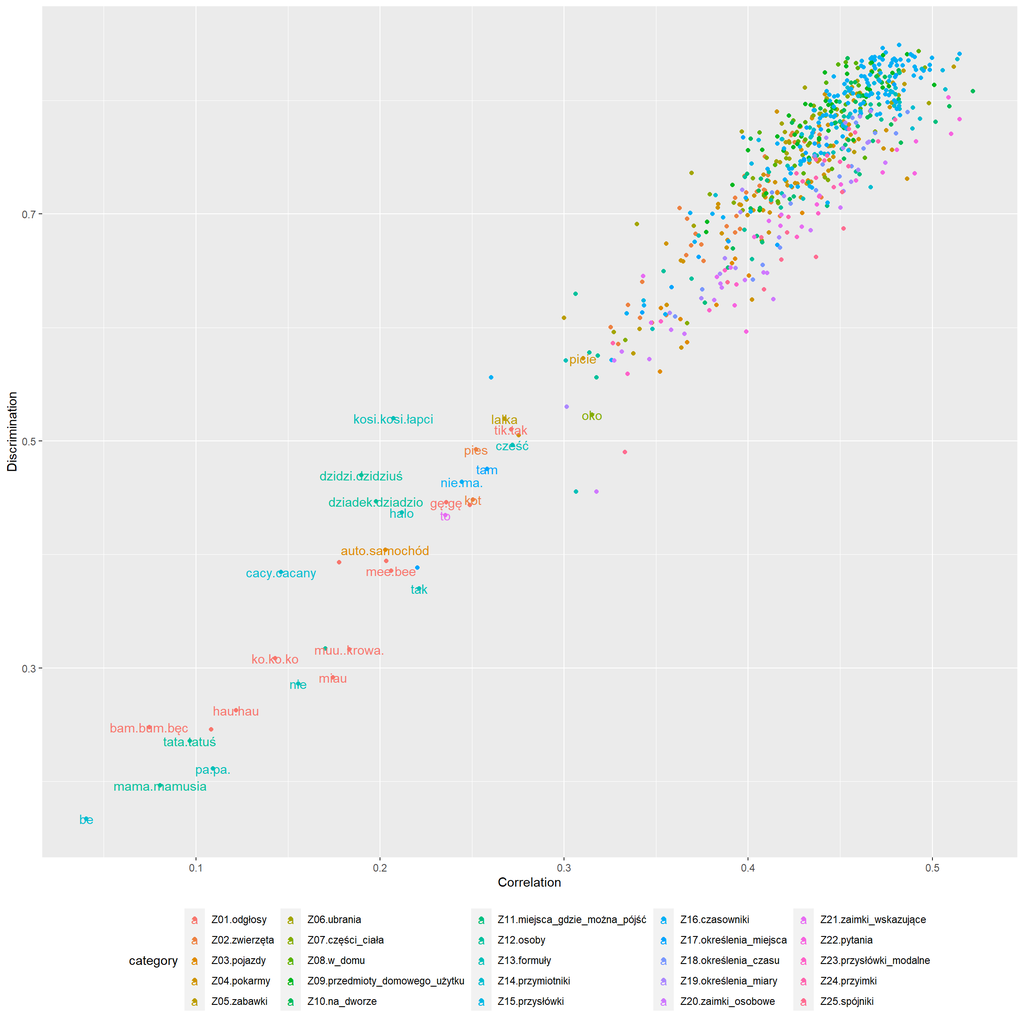

```r
ggplot(ctt_params, aes(cors2, dscrmn, label=position, colour=category)) +
  geom_point() +
  xlab("Correlation") +
  ylab("Discrimination") +
  geom_text(aes(label=ifelse(dscrmn < 0.6 & cors2 < 0.35, as.character(position),'')), check_overlap = T) +
  theme(legend.position = "bottom")
```

# Low correlation <=> easy items?

Colour by difficulties:

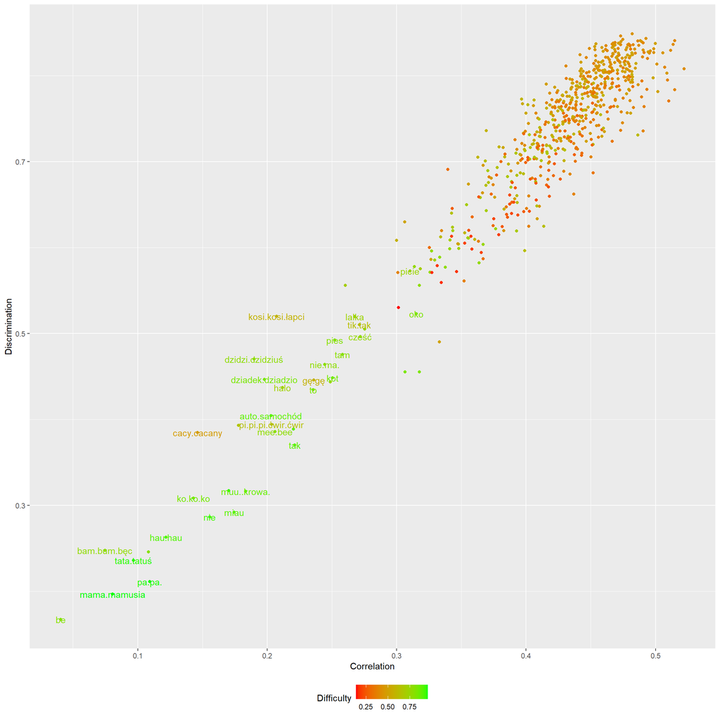

```r
ggplot(ctt_params, aes(cors2, dscrmn, label=position, colour=dffclt)) +
  geom_point() +
  xlab("Correlation") +
  ylab("Discrimination") +
  geom_text(aes(label=ifelse(dscrmn < 0.6 & cors2 < 0.35, as.character(position),'')), check_overlap = T) +
  theme(legend.position = "bottom") +
  scale_color_gradient(low="red", high="green") +
  labs(colour = "Difficulty")
```

# Best CTT items vs. best IRT items

Check how many best items are the same as those selected in simulations:

```r
load("Data/best146")
ctt_params$dist <- sqrt(ctt_params$dscrmn^2 + ctt_params$cors2^2) #Count distance of points from (0,0):
ctt_params_o <- ctt_params[order(ctt_params$dist, decreasing = T), ] #Order by distance
ctt_params_s <- ctt_params_o[1:146, ] #Select 146 'best' items
table(ctt_params_s$number.ws %in% best_items$number.ws)
```

```
##
## FALSE  TRUE
##   136    10
```

Only 10…

Selet more:

```r
ctt_params_s <- ctt_params_o[1:200, ] #Select 200 'best' items
table(ctt_params_s$number.ws %in% best_items$number.ws)
```

```
##
## FALSE  TRUE
##   187    13
```

Check relationship between CTT discrimination and IRT discrimination:

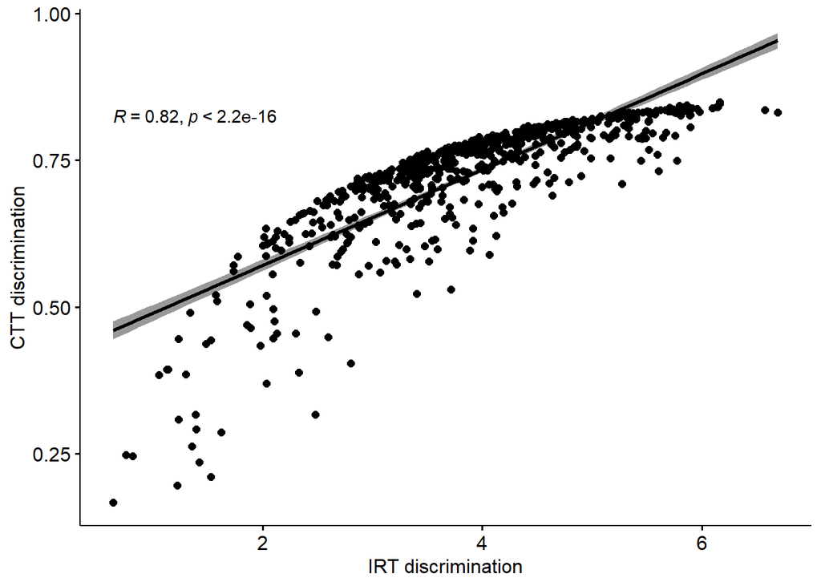

```r
load("Data/mirt_model_601q")
mirt_params <- as.data.frame(coef(mirt_model, simplify = TRUE)$items)[1:2]

ggscatter(data.frame(irt_dscrmn = mirt_params$a1, ctt_dscrmn = ctt_params$dscrmn), x = "irt_dscrmn", y = "ctt_dscrmn",
  add = "reg.line", conf.int = TRUE,
  cor.coef = TRUE, cor.method = "pearson",
  xlab = "IRT discrimination", ylab = "CTT discrimination")
```

Check relationship between CTT difficulty and IRT difficulty:

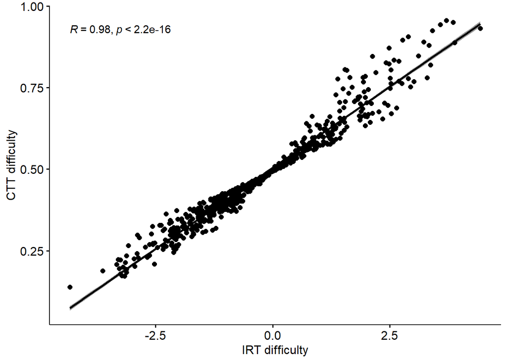

```r
ggscatter(data.frame(irt_diff = mirt_params$d, ctt_diff= ctt_params$dffclt), x = "irt_diff", y = "ctt_diff",
  add = "reg.line", conf.int = TRUE,
  cor.coef = TRUE, cor.method = "pearson",
  xlab = "IRT difficulty", ylab = "CTT difficulty")
```

# Difficulty vs. age for particular item

Check ‘be’ (months means):

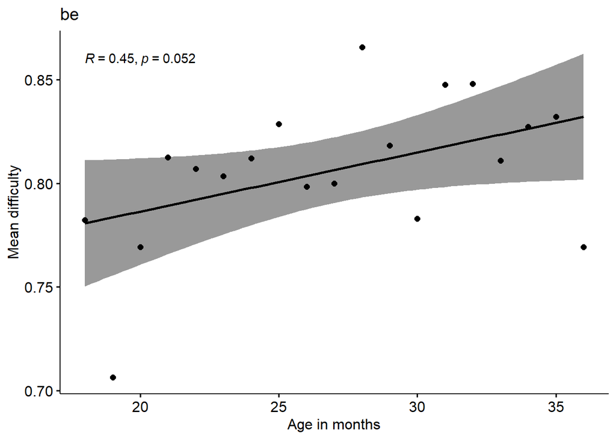

```r
word <- "be"
nr <- ctt_params[ctt_params$position == "be", "number.ws"]

ggscatter(data.frame(months = unique(responses_demo$months), dffclts = dffclts_months[, nr]), x = "months", y = "dffclts",
  add = "reg.line", conf.int = TRUE,
  cor.coef = TRUE, cor.method = "pearson",
  xlab = "Age in months", ylab = "Mean difficulty", title = word)
```